# (10) Introduction to dplyr

Lasse Ruokolainen, Bilot Consulting Oy

[`dplyr`](https://dplyr.tidyverse.org/) is one of the most powerful tools for data engineering. It is a grammar of data manipulation, providing a consistent set of verbs that help you solve the most common data manipulation challenges. In essence, `dplyr` is kind of doing SQL on `data.frames`, but in a much easier way. At the core of working with `dplyr` is the `%>%` pipe operator, which allows one to chain several consecutive operations.

# 1 SELECT from data.frame

In SQL, the most common syntax is `SELECT * FROM table`, which return all content of `table` in a database. The same operation in `dplyr` is rather silly, but this is how it works:

```r
library(dplyr)
data(mpg,package = 'ggplot2')

mpg %>%
  select(everything())
```

| manufacturer | model | displ | year | cyl | trans | drv | cty | hwy | fl | class |
| --- | --- | --- | --- | --- | --- | --- | --- | --- | --- | --- |
| audi | a4 | 1.8 | 1999 | 4 | auto(l5) | f | 18 | 29 | p | compact |
| audi | a4 | 1.8 | 1999 | 4 | manual(m5) | f | 21 | 29 | p | compact |
| audi | a4 | 2.0 | 2008 | 4 | manual(m6) | f | 20 | 31 | p | compact |
| audi | a4 | 2.0 | 2008 | 4 | auto(av) | f | 21 | 30 | p | compact |
| audi | a4 | 2.8 | 1999 | 6 | auto(l5) | f | 16 | 26 | p | compact |
| audi | a4 | 2.8 | 1999 | 6 | manual(m5) | f | 18 | 26 | p | compact |
| audi | a4 | 3.1 | 2008 | 6 | auto(av) | f | 18 | 27 | p | compact |
| audi | a4 quattro | 1.8 | 1999 | 4 | manual(m5) | 4 | 18 | 26 | p | compact |
| audi | a4 quattro | 1.8 | 1999 | 4 | auto(l5) | 4 | 16 | 25 | p | compact |
| audi | a4 quattro | 2.0 | 2008 | 4 | manual(m6) | 4 | 20 | 28 | p | compact |

[output cut: 224 more lines]

Usually, one is interested in selecting only certain variables, which can be optionally rename them on the fly:

```r
mpg %>%
  select(manufacturer,
         fuel_type = fl,
         city_mpg = cty)
```

| manufacturer | fuel_type | city_mpg |
| --- | --- | --- |
| audi | p | 18 |
| audi | p | 21 |
| audi | p | 20 |
| audi | p | 21 |
| audi | p | 16 |
| audi | p | 18 |
| audi | p | 18 |
| audi | p | 18 |
| audi | p | 16 |
| audi | p | 20 |

[output cut: 224 more lines]

To *exclude* rather than select variables, use `-` sign in front of the variable name:

```r
mpg %>%
  select(-trans,-model,-class)
```

| manufacturer | displ | year | cyl | drv | cty | hwy | fl |
| --- | --- | --- | --- | --- | --- | --- | --- |
| audi | 1.8 | 1999 | 4 | f | 18 | 29 | p |
| audi | 1.8 | 1999 | 4 | f | 21 | 29 | p |
| audi | 2.0 | 2008 | 4 | f | 20 | 31 | p |
| audi | 2.0 | 2008 | 4 | f | 21 | 30 | p |
| audi | 2.8 | 1999 | 6 | f | 16 | 26 | p |
| audi | 2.8 | 1999 | 6 | f | 18 | 26 | p |
| audi | 3.1 | 2008 | 6 | f | 18 | 27 | p |
| audi | 1.8 | 1999 | 4 | 4 | 18 | 26 | p |
| audi | 1.8 | 1999 | 4 | 4 | 16 | 25 | p |
| audi | 2.0 | 2008 | 4 | 4 | 20 | 28 | p |

[output cut: 224 more lines]

To select only the top rows by variable type, one can use `select_if()` selector function and pipe the result to `head()` function:

```r
mpg %>%
  select_if(is.character) %>%
#  select_if(is.integer) %>%
  head(10)
```

| manufacturer | model | trans | drv | fl | class |
| --- | --- | --- | --- | --- | --- |
| audi | a4 | auto(l5) | f | p | compact |
| audi | a4 | manual(m5) | f | p | compact |
| audi | a4 | manual(m6) | f | p | compact |
| audi | a4 | auto(av) | f | p | compact |
| audi | a4 | auto(l5) | f | p | compact |
| audi | a4 | manual(m5) | f | p | compact |
| audi | a4 | auto(av) | f | p | compact |
| audi | a4 quattro | manual(m5) | 4 | p | compact |
| audi | a4 quattro | auto(l5) | 4 | p | compact |
| audi | a4 quattro | manual(m6) | 4 | p | compact |

Conveniently, `dplyr` also allows selection by partial matching:

```r
mpg %>%
  # Match to string in different ways:
  select(contains('manu'),
         starts_with('y'),
         ends_with('y')) %>%
  head()
```

| manufacturer | year | cty | hwy |
| --- | --- | --- | --- |
| audi | 1999 | 18 | 29 |
| audi | 1999 | 21 | 29 |
| audi | 2008 | 20 | 31 |
| audi | 2008 | 21 | 30 |
| audi | 1999 | 16 | 26 |
| audi | 1999 | 18 | 26 |

# 2 FILTER data.frame rows

In addition to selecting columns, one often also wants to subset rows in a `data.frame` based on some conditions. This is akin to the `WHERE` clause in SQL. Different filters can be combined in a single `filter()`-function call:

```r
mpg %>%
  filter(
    # Filter with regexp:
    manufacturer %in% grep('^h',manufacturer,value = T),
    # Numeric filter:
    displ > 1.6,
    # Character filter:
    class == 'midsize')
```

| manufacturer | model | displ | year | cyl | trans | drv | cty | hwy | fl | class |
| --- | --- | --- | --- | --- | --- | --- | --- | --- | --- | --- |
| hyundai | sonata | 2.4 | 1999 | 4 | auto(l4) | f | 18 | 26 | r | midsize |
| hyundai | sonata | 2.4 | 1999 | 4 | manual(m5) | f | 18 | 27 | r | midsize |
| hyundai | sonata | 2.4 | 2008 | 4 | auto(l4) | f | 21 | 30 | r | midsize |
| hyundai | sonata | 2.4 | 2008 | 4 | manual(m5) | f | 21 | 31 | r | midsize |
| hyundai | sonata | 2.5 | 1999 | 6 | auto(l4) | f | 18 | 26 | r | midsize |
| hyundai | sonata | 2.5 | 1999 | 6 | manual(m5) | f | 18 | 26 | r | midsize |
| hyundai | sonata | 3.3 | 2008 | 6 | auto(l5) | f | 19 | 28 | r | midsize |

Alternatively, you can also `slice()` rows by index:

```r
set.seed(78)
mpg %>%
  # take a random sample of 10 cars:
  slice(sample(n(),10))
```

| manufacturer | model | displ | year | cyl | trans | drv | cty | hwy | fl | class |
| --- | --- | --- | --- | --- | --- | --- | --- | --- | --- | --- |
| toyota | 4runner 4wd | 4.7 | 2008 | 8 | auto(l5) | 4 | 14 | 17 | r | suv |
| toyota | corolla | 1.8 | 1999 | 4 | auto(l4) | f | 24 | 33 | r | compact |
| mercury | mountaineer 4wd | 4.6 | 2008 | 8 | auto(l6) | 4 | 13 | 19 | r | suv |
| subaru | impreza awd | 2.5 | 2008 | 4 | manual(m5) | 4 | 20 | 27 | r | compact |
| toyota | corolla | 1.8 | 2008 | 4 | auto(l4) | f | 26 | 35 | r | compact |
| ford | mustang | 3.8 | 1999 | 6 | auto(l4) | r | 18 | 25 | r | subcompact |
| dodge | ram 1500 pickup 4wd | 4.7 | 2008 | 8 | auto(l5) | 4 | 13 | 17 | r | pickup |
| ford | explorer 4wd | 4.0 | 1999 | 6 | auto(l5) | 4 | 14 | 17 | r | suv |
| chevrolet | c1500 suburban 2wd | 5.3 | 2008 | 8 | auto(l4) | r | 14 | 20 | r | suv |
| ford | mustang | 4.0 | 2008 | 6 | manual(m5) | r | 17 | 26 | r | subcompact |

# 3 CALCULATE variables

A central part of data engineering is to generate new variables to the data. To this end, `dplyr` has a function `mutate()`:

```r
mpg %>%
  mutate(avg_mpg = (cty+hwy)/2) %>%
  select(model,displ,drv,fl,avg_mpg) %>%
  head()
```

| model | displ | drv | fl | avg_mpg |
| --- | --- | --- | --- | --- |
| a4 | 1.8 | f | p | 23.5 |
| a4 | 1.8 | f | p | 25.0 |
| a4 | 2.0 | f | p | 25.5 |
| a4 | 2.0 | f | p | 25.5 |
| a4 | 2.8 | f | p | 21.0 |
| a4 | 2.8 | f | p | 22.0 |

While `mutate` adds new variables on top of the existing variables, it is also possible to extract a new variable. This is done using the `transmute()` function:

```r
mpg %>%
  transmute(avg_mpg = (cty+hwy)/2) %>%
  head()
```

| avg_mpg |
| --- |
| 23.5 |
| 25.0 |
| 25.5 |
| 25.5 |
| 21.0 |
| 22.0 |

`mutate` can also be used to modify existing variables:

```r
mpg %>%
  # Convert all characters to factor:
  mutate_if(is.character,as.factor) %>%
  # Scale numeric features:
  mutate_if(is.numeric,scale) %>%
  select(manufacturer, displ) %>%
  summary()
```

```
     manufacturer       displ.V1
 dodge     :37    Min.   :-1.4488036
 toyota    :34    1st Qu.:-0.8295889
 volkswagen:27    Median :-0.1329724
 ford      :25    Mean   : 0.0000000
 chevrolet :19    3rd Qu.: 0.8732515
 audi      :18    Max.   : 2.7308955
 (Other)   :74
```

- **Do it yourself**: Calculate the average and SD of city fuel consumption, but only for cars with automatic transmission.

```r
# your code comes here:
```

# 4 CASE WHEN

In SQL, CASE WHEN is a handy for either categorising or re-categorising variables. In `dplyr`, there is a function `case_when` that does exactly the same thing:

```r
mpg %>%
  mutate(avg_mpg = (cty+hwy)/2) %>%
  mutate(mpg_class = case_when(avg_mpg<18 ~ 'high',
                               avg_mpg>=18 & avg_mpg<26 ~ 'medium',
                               avg_mpg>=26 ~ 'low')) %>%
  select(manufacturer,model,mpg_class) %>%
  slice(sample(nrow(mpg),10))
```

| manufacturer | model | mpg_class |
| --- | --- | --- |
| chevrolet | malibu | medium |
| dodge | ram 1500 pickup 4wd | high |
| ford | explorer 4wd | high |
| honda | civic | low |
| hyundai | tiburon | medium |
| volkswagen | new beetle | low |
| volkswagen | gti | medium |
| volkswagen | passat | medium |
| ford | f150 pickup 4wd | high |
| ford | mustang | medium |

# 5 GROUP BY

Typically, data contains some structure and one is interested in making calculations within those structures or performing aggregations across them. In SQL there is a `GROUP BY` statement and the same thing exists also in `dplyr`.

For example, to broadcast aggregated variable within groups:

```r
mpg %>%
  group_by(manufacturer) %>%
  mutate(avg_cty = round(mean(cty),1)) %>%
  select(ends_with('y')) %>%
  head()
```

| manufacturer | cty | hwy | avg_cty |
| --- | --- | --- | --- |
| audi | 18 | 29 | 17.6 |
| audi | 21 | 29 | 17.6 |
| audi | 20 | 31 | 17.6 |
| audi | 21 | 30 | 17.6 |
| audi | 16 | 26 | 17.6 |
| audi | 18 | 26 | 17.6 |

Aggregate data at grouping level:

```r
mpg %>%
  group_by(manufacturer, class) %>%
  summarize(avg_hwy = round(mean(hwy),1),
            num_cars = n()) %>%
  head()
```

| manufacturer | class | avg_hwy | num_cars |
| --- | --- | --- | --- |
| audi | compact | 26.9 | 15 |
| audi | midsize | 24.0 | 3 |
| chevrolet | 2seater | 24.8 | 5 |
| chevrolet | midsize | 27.6 | 5 |
| chevrolet | suv | 17.1 | 9 |
| dodge | minivan | 22.4 | 11 |

- **Do it yourself**: Calculate the average anomaly of highway fuel consumption per model, with respect to average highway fuel consumption across the entire data.

```r
# your code comes here:
```

# 6 JOINING data

Joins are an important tool when working with multi-faceted data, typically in SQL. These you can do without a problem in `dplyr`.

**LEFT JOIN**, which returns all rows in the left table:

```r
left_join(band_instruments,band_members,by='name')
```

| name | plays | band |
| --- | --- | --- |
| John | guitar | Beatles |
| Paul | bass | Beatles |
| Keith | guitar | NA |

**INNER JOIN**, which returns all rows that have a matching key in both tables:

```r
inner_join(band_instruments,band_members,by='name')
```

| name | plays | band |
| --- | --- | --- |
| John | guitar | Beatles |
| Paul | bass | Beatles |

**FULL JOIN** returns all rows:

```r
full_join(band_instruments,band_members,by='name')
```

| name | plays | band |
| --- | --- | --- |
| John | guitar | Beatles |
| Paul | bass | Beatles |
| Keith | guitar | NA |
| Mick | NA | Stones |

**SEMI JOIN**, return all rows from left table where there are matching values in right table, keeping just columns from left table:

```r
semi_join(band_instruments,band_members,by='name')
```

| name | plays |
| --- | --- |
| John | guitar |
| Paul | bass |

A semi join differs from an inner join because an inner join will return one row of left table for each matching row of right table, where a semi join will never duplicate rows of left table.

**ANTI JOIN**, which returns only those rows in the left table that do not occur in the right table:

```r
anti_join(band_instruments,band_members,by='name')
```

| name | plays |
| --- | --- |
| Keith | guitar |

# 7 ADVANCED manipulation

The `PimaIndiansDiabetes` contains many 0-values that should actually be treated as missing information. Such values are usually not allowed in statistical models and thus we need to do something about them.

First, we need to do some preparations:

```r
# Get data:
data(PimaIndiansDiabetes, package='mlbench')

# Define custom function to replaxce 0's with NA:
repl0 = function(x) ifelse(x==0,NA,x)
# Define custom function to replaxce NA's with mean:
replNA = function(x) ifelse(is.na(x),mean(x,na.rm = T),x)

# Define variables to modify:
nam = setdiff(names(PimaIndiansDiabetes),c('pregnant','diabetes'))
```

And then we can proceed to manipulating the data:

```r
PimaIndiansDiabetes %>%
  # Apply function repl0 to selected features:
  mutate_at(vars(nam), repl0) %>%
  # Apply function replNA to selected features:
  mutate_at(vars(nam), replNA) %>%
  # Scale numeric features:
  mutate_if(is.numeric,scale) -> df

head(df)
```

|  | pregnant | glucose | pressure | triceps | insulin | mass | pedigree | age | diabetes |
| --- | --- | --- | --- | --- | --- | --- | --- | --- | --- |
| 1 | 0.6395305 | 0.8645447 | -0.03349641 | 0.66506871 | 0.0000000 | 0.1661834 | 0.4681869 | 1.42506672 | pos |
| 2 | -0.8443348 | -1.2053760 | -0.52951396 | -0.01745201 | 0.0000000 | -0.8519760 | -0.3648230 | -0.19054773 | neg |
| 3 | 1.2330766 | 2.0145006 | -0.69485314 | 0.00000000 | 0.0000000 | -1.3319654 | 0.6040037 | -0.10551539 | pos |
| 4 | -0.8443348 | -1.0739525 | -0.52951396 | -0.69997273 | -0.7239170 | -0.6337989 | -0.9201630 | -1.04087112 | neg |
| 5 | -1.1411079 | 0.5031299 | -2.67892334 | 0.66506871 | 0.1464551 | 1.5479712 | 5.4813370 | -0.02048305 | pos |
| 6 | 0.3427574 | -0.1868436 | 0.13184277 | 0.00000000 | 0.0000000 | -0.9974273 | -0.8175458 | -0.27558007 | neg |

Convert the resulting data into `tidy`-format for effective visualisation:

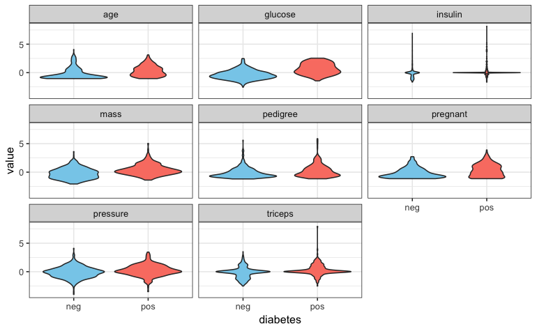

```r
library(tidyr)
df %>%
  gather(key = 'feature', value = 'value', -diabetes) %>%
  ggplot(aes(diabetes,value,fill=diabetes))+
    scale_fill_manual(values=c('skyblue','salmon'))+
    geom_violin()+
    facet_wrap(~feature)+
    theme_bw()+
    theme(legend.position = 'n')
```